# Final Project Video Games

Tommy Lam, Eric Le, Maya Nair, Assaf Vayner

5/17/2020

## Summary Information

### Which top 3 publishers sold the most games in North America, Europe, Japan, and globally?

One piece of information we were interested to look further into was what publishers were dominant in various regions as well as which publishers were dominant worldwide. In North America, the top 3 publishers in 2016 were Nintendo , Electronic Arts and Activision. Next, in Europe, the top 3 publishers were Nintendo , Electronic Arts and Activision. Last, in Japan the top 3 publishers were Nintendo , Namco Bandai Games and Konami Digital Entertainment. Overall, the top 3 publishers globally were Nintendo , Electronic Arts and Activision. Overall, it was interesting to see that Nintendo was one of the top publishers across the board.

### What are the top 3 game genres in a given region based on sales?

From our second question, we looked to find which genres were most popular in certain regions depending on the sales of various games. In North America, the top 3 genres were Action , Sports and Shooter. In Japan, the top 3 genres were Role-Playing , Action and Sports. In Europe, the top 3 genres were Action , Sports and Shooter. Lastly, the top 3 genres worldwide, were Action , Sports and Shooter. From this, we found that Action, Sports, and shooter games were prodominantly popular with one outlier being Role-Playing games in Japan.

### Do certain consoles get played more in certain regions?

Next, we sought to find which consoles of 2016 were most popular in given regions. In North America, the top 3 consoles were 2600 , 3DO and 3DS, in Japan, the top 3 consoles were 2600 , 3DO and 3DS, and in Europe, the top 3 consoles were 2600 , 3DO and 3DS. Interestingly enough, we found that the same consoles appeared to dominate overall no matter the region we analyzed.

### What age restriction gets the least and most playtime?

Our next question we were interested in answering, is what age restriction had the least and most playtime on Steam. From this, we discovered that the age restriction with the least playtime on Steam was, 7, and the age restriction with the most playtime was 0.

### Are people playing more time on multiplayer games?

According to data collected regarding games on steam, there were 1825 multiplayer games (including online and local multiplayer games) out of 6170 games. The average play time across all multiplayer games was 289.88 minutes while it was 367.48 for non-multiplayer games showing that non-multiplayer games generally get played for longer by each owner.

## Table of Most Successful Publishers

| Publisher | NA Sales | EU Sales | JP Sales | Other Sales | Global Sales | Global Popularity | Popularity rank |
| --- | --- | --- | --- | --- | --- | --- | --- |
| Nintendo | 775.61 | 390.05 | 454.38 | 86.23 | 1706.28 | 40168.012 | 4 |
| Electronic Arts | 599.50 | 373.91 | 14.35 | 128.96 | 1116.96 | 3097.211 | 8 |
| Activision | 432.59 | 215.90 | 6.71 | 75.81 | 731.16 | 2291.510 | 11 |
| Sony Computer Entertainment | 266.17 | 186.56 | 74.15 | 79.67 | 606.48 | 263163.027 | 2 |
| Ubisoft | 252.74 | 161.99 | 7.52 | 49.18 | 471.61 | 3345.739 | 6 |
| Take-Two Interactive | 222.94 | 119.25 | 5.93 | 55.72 | 403.82 | 3215.101 | 7 |
| THQ | 207.72 | 93.78 | 5.01 | 31.89 | 338.44 | 2505.704 | 9 |
| Konami Digital Entertainment | 91.90 | 68.98 | 91.40 | 29.93 | 282.39 | 13268135.775 | 1 |
| Sega | 108.61 | 80.66 | 57.06 | 23.81 | 270.35 | 71633.767 | 3 |
| Namco Bandai Games | 69.90 | 42.16 | 127.85 | 14.60 | 254.62 | 11460.999 | 5 |
| Microsoft Game Studios | 157.43 | 68.64 | 3.30 | 18.91 | 248.32 | 2438.406 | 10 |

## Barchart Comparing Genres and Publisher

The following barcharts look at different genres to see which games and publishers sold the most globally. These barcharts looked at genre and global sales exceeding 3 standard deviations from the mean global sales in order to focus on the top performing games without cluttering the data. This barchart is included because it is clear to see which games performed the most and which publisher produced the games. The uage of color to differentiate publishers also adds to the clarity of the chart. The 2 genres that we tested were sports and shooter. For sports games, we can see that the top game sales are all from Nintendo and their Wii fit and Wii sports games. For shooter games, we can tell that Call of duty games from Activision made the most sum of money, but Duck Hunt actually beats out all of the other games when compared individually.

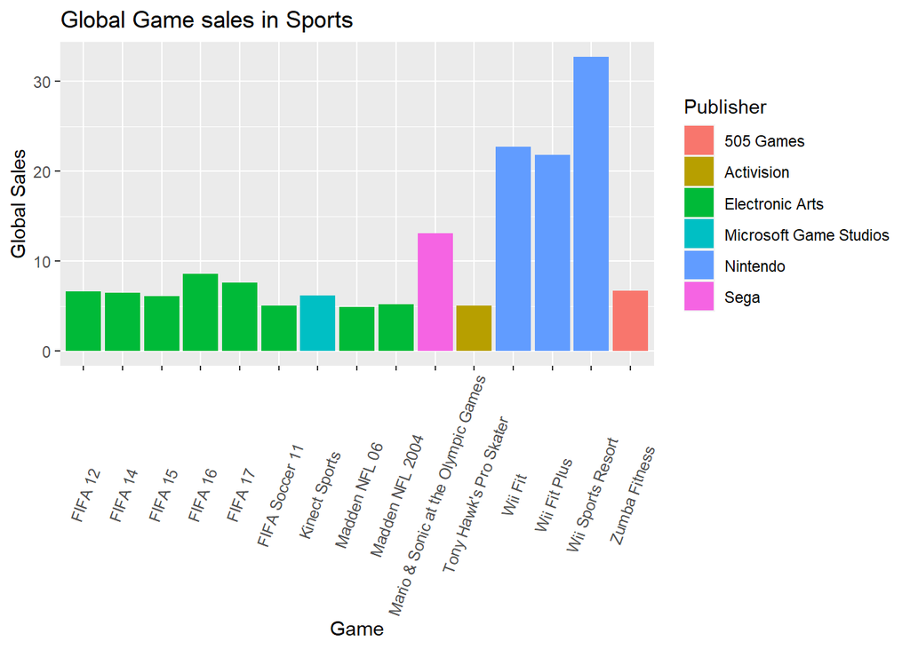

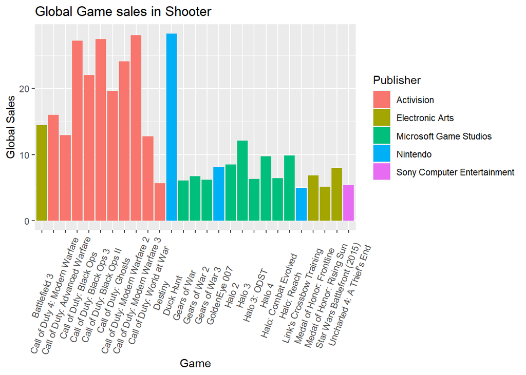

## 3D Scatter plot of game sales

The following scatterplot is interactive to help see how well each game performed in specific regions and globally. For the axis, we have North American, Japan, and European sales, while having the color scale with global sales. We decided to do an interactive scatter plot for this part in order for the reader to see how the game sold in each region specifically, and the color scaling helps see which games did the best globally. While hovering over each dot, you can see the stats broken down along with name and genre. The filtered data was set to 6 standard deviations above the mean, but there are still many games so we can tell that there have been more games that performed worse than games that have been successful. We can see from the games that sold 25M +, the US contributed the most out of the regions tested and so we can tell that most of the game sales come from the US. The genres of popular games are also diverse being Platform, Puzzle, Shooter, and Role-playing so that means there is variety when it comes to popular games and not one genre is dominating the market.

[interactive chart not shown]